# Practical phylogenetic methods for linguistic typology

Erich Round

2021-11-04

# Introduction

A perennial task in typology is the characterisation of frequencies of traits of interest among the world’s languages. The scientific interest of such questions typically lies not merely in the contingent facts of today’s particular languages and language families, rather the goal is to characterise the nature of human language in general, using today’s contingent empirical data as evidence. One of the key challenges that makes this task difficult to carry out in a principled way is that languages are historically related to each other. This document is a practical introduction to the use of *phylogenetic comparative methods*, which will help to meet this challenge in a principled way.

**Preparation and session set up**

This tutorial is based on R. If you have not installed R or are new to it, you will find an introduction to and more information how to use R [here](https://slcladal.github.io/intror.html). For this tutorials, we need to install certain *packages* from an R *library* so that the scripts shown below are executed without errors. Before turning to the code in subsequent sections, please first install the packages by running the code below this paragraph. If you have already installed the packages mentioned below, then you can skip ahead and ignore this section. To install the necessary packages, simply run the following code - it may take some time (between 1 and 5 minutes to install all of the libraries so you do not need to worry if it takes some time).

```r
# set options
options(stringsAsFactors = F)         # no automatic data transformation
options("scipen" = 100, "digits" = 4) # suppress math annotation
# install packages
install.packages("tidyverse")
install.packages("flextable")
install.packages("devtools")
#install.packages("phytools")
# install klippy for copy-to-clipboard button in code chunks
devtools::install_github("rlesur/klippy")
devtools::install_github("erichround/phyloWeights",
                         dependencies = T,
                         INSTALL_opts = c("--no-multiarch"))
devtools::install_github("erichround/glottoTrees",
                         dependencies = T,
                         INSTALL_opts = c("--no-multiarch"))
```

Next, we activate the packages.

```r
# activate packages
library(tidyverse)
library(flextable)
library(phyloWeights)
library(glottoTrees)
library(ape)
# activate klippy for copy-to-clipboard button
klippy::klippy()
```

Once you have installed R, RStudio, and have also initiated the session by executing the code shown above, you are good to go.

## 0.1 An intuitive introduction to the challenge of genealogy

To get an intuitive notion of the challenge that is presented by the genealogical relatedness of languages, consider the small language family pictured in @ref(fig:SOV-tree). It contains four languages, which are either SOV or SVO. The question is: What proportion of this family is SOV? Should you just count the languages, in which case the answer is literally 75%? This answer may seem not quite right, because now one half of the family is counting three times as much as the other half, just because it had the fortune of containing more languages. Put another way, the figure of 75% is strongly influenced by contingencies of history.

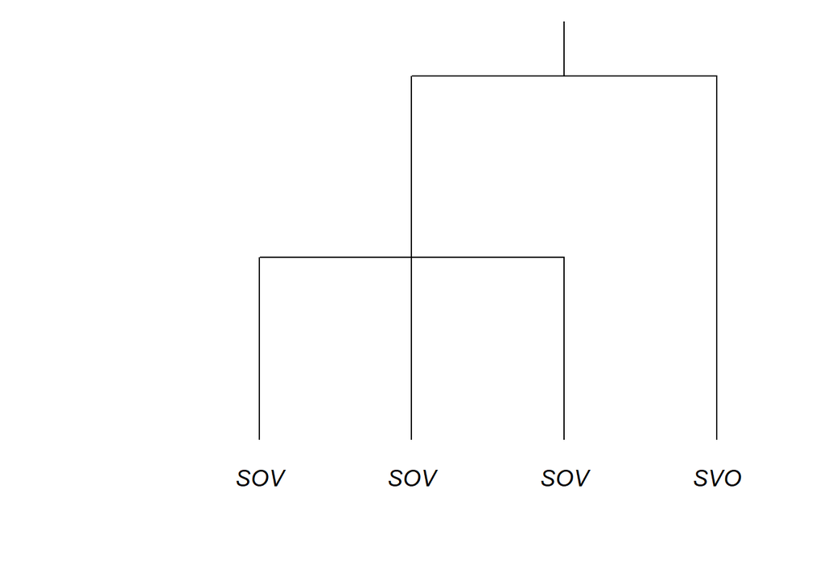

In a LADAL seminar on 4 November, 2021 (Macklin-Cordes and Round 2021b) and in a related journal article (Macklin-Cordes and Round 2021a), Jayden Macklin-Cordes and I review some of history of thinking in linguists’ attempts to account for historical relatedness of exactly this kind when comparing across languages. We also explain how *phlyogenetic comparative methods* present the most principled response to it developed so far. We recommend reviewing either of these sources, since they cover the scientific content which corresponds to the practical, technical content in this tutorial. Here, we will not review the scientific content at any length.

This document provides a guide to the practical use of phylogenetic comparative methods for linguistic typology, specifically, the calculation of genealogically-sensitive proportions and averages. These are methods which provide an answer to the question: “When characterising the frequencies of traits among the world’s languages, how can we take genealogy into account?” Here we cover two methods for calculating genealogically-sensitive proportions and averages: the ‘ACL’ method (Altschul, Carroll, and Lipman 1989) and the ‘BM’ method (Stone and Sidow 2007).

Because a key part of this kind of analysis is the preparation of a phylogenetic tree, an important component of the tutorial will be about how such trees can be prepared.

The tutorial is divided into four main sections. Section @ref(r-trees) is an introduction to how trees are represented in R. Section @ref(averages) discusses the calculation of genealogically-sensitive proportions and averages. Section @ref(glottolog) explains how typologists can prepare phylogenetic trees by adapting resources freely available from glottolog.com (Hammarström et al. 2021). And Section @ref(example) provides a worked example used in a typological investigation of sonority sequencing by Yin (2020).

Much of the discussion below is an introduction to the functionality of two R packages, `glottoTrees` (E. R. Round 2021a) and `phyloWeights` (E. R. Round 2021b), which have been specifically written for these tasks. The text of this tutorial is taken largely from the Supplementary Materials section S1 of Macklin-Cordes and Round (2021a).

# 1 Trees in R

This section discusses how trees are created, manipulated and plotted in R. Terminology we will use includes: *tips* at the ends of trees, which in a linguistic tree would usually be the languages or lects; the *branches* of a tree; the *interior nodes* or just *nodes* of a tree, where branches join together; and the *root* of the tree, its deepest node. R will represent trees as complex objects, in which the tips, nodes and branches all appear, along with labels for the tips and nodes.

One of the simplest methods of constructing a tree in R begins with a description of the tree using a form a bracketing notation known as the *Newick* standard (Felsenstein, n.d.). In its simplest form, a tree is represented in Newick format by a set of tip labels grouped by parentheses, separated by commas, and ending with a semicolon. For example, here is a string that represents a tree with four tips, `A`, `B`, `C` and `D`, which we assign to the object `my_newick`:

```r
my_newick <- "(((A,B),C),D);"
```

A Newick-formatted string can then be converted to a tree object by supplying it as the `text` argument of the function `read.tree()`, from the `ape` package:

```r
my_tree <- read.tree(text = my_newick)
```

We can plot the tree using the `plot()` function:

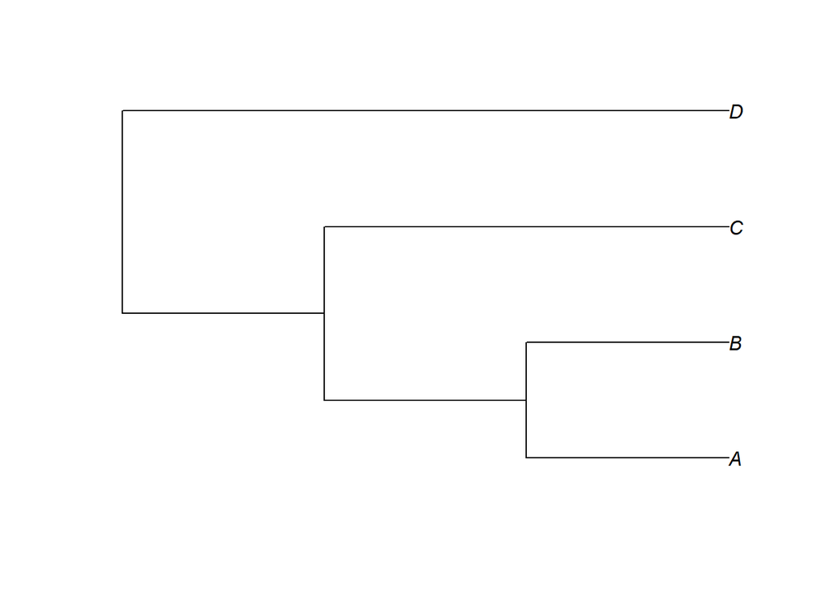

```r
plot(my_tree)
```

By default, trees in R are plotted horizontally following the convention in biology. The `glottoTrees` package provides a function `plot_glotto()` which plots trees in a more typical, downward-running linguistic format, as below.

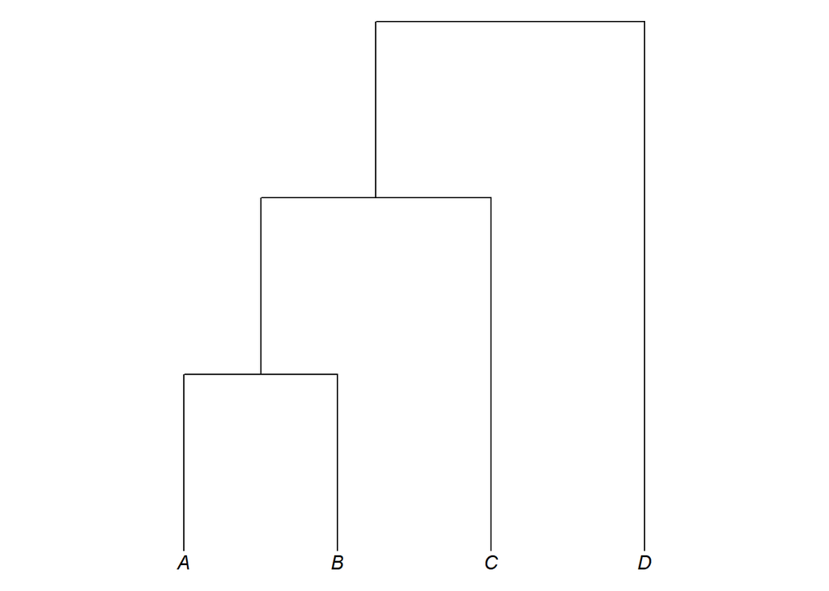

```r
plot_glotto(my_tree)
```

The tree object `my_tree` which we defined above did not include information about branch lengths. In Newick format, branch lengths are written with a preceding colon and appear directly after a language or the closing bracket for a subgroup:

```r
my_newick2 <- "(((A:4,B:4):1,C:5):3,D:8);"
```

Converting this to a tree object and plotting it:

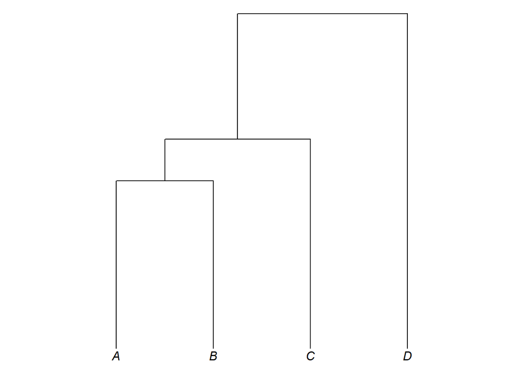

```r
my_tree2 <- read.tree(text = my_newick2)
plot_glotto(my_tree2)
```

Trees can have labels not only for their tips, but also for their internal nodes. In linguistics, an internal node of a tree may be interpreted taxonomically, as representing a subgroup and labeled accordingly, or genealogically, as a proto-language from which the subgroup descends and labeled accordingly. In Newick format, labels for internal nodes are placed directly after a closing parenthesis. For example, here we add labels that reflect a genealogical interpretation of the nodes:

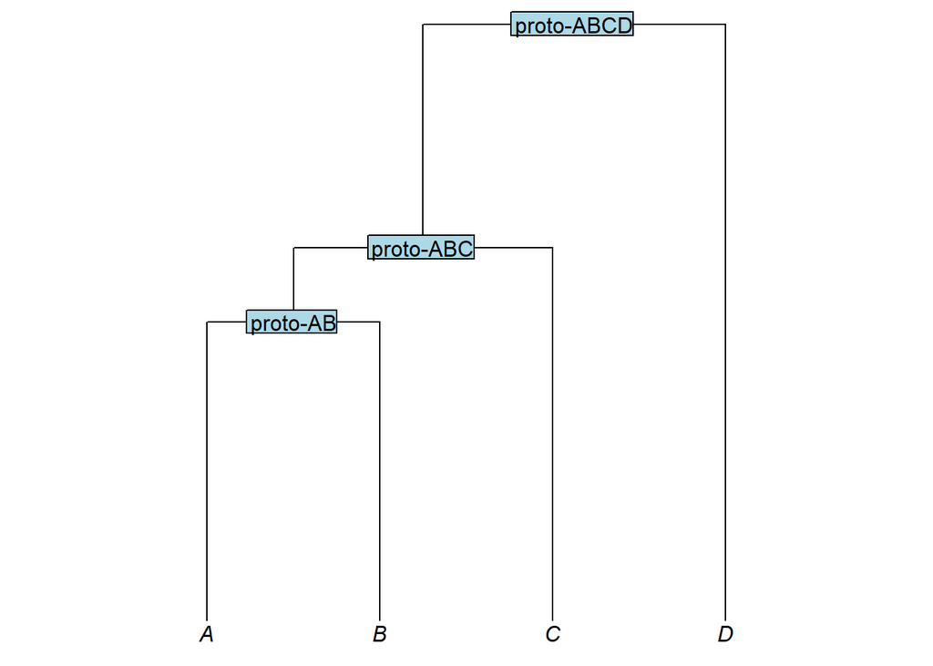

```r
my_newick3 <- "(((A:4,B:4)proto-AB:1,C:5)proto-ABC:3,D:8)proto-ABCD;"
my_tree3 <- read.tree(text = my_newick3)
plot_glotto(my_tree3)
```

Technically speaking, trees are represented by R as objects with a customised class called `phylo`.

```r
class(my_tree3)
```

```
## [1] "phylo"
```

A `phylo` object stores information about the tree *topology* (i.e., its branching structure), the branch lengths, and the labels of the tips and nodes. In R we often use the `$` operator to access one object that is contained inside another. For instance, the object `y` contained within the larger object `x` would be referred to as `x$y`. Here are some examples:

```r
my_tree3$edge.length
```

```
## [1] 3 1 4 4 5 8
```

```r
my_tree3$tip.label
```

```
## [1] "A" "B" "C" "D"
```

```r
my_tree3$node.label
```

```
## [1] "proto-ABCD" "proto-ABC"  "proto-AB"
```

Another object class in R, related to the `phylo` class, is the `multiPhylo` class. Objects of the `multiPhylo` class are used to store multiple `phylo` trees in a single, larger object.

```r
newick_a <- "(((A:4,B:4):1,C:5):3,D:8);"
newick_b <- "((A:2,B:2):1,(C:1,D:1,E:1):2);"
tree_a <- read.tree(text = newick_a)
tree_b <- read.tree(text = newick_b)
my_multiPhylo <- c(tree_a, tree_b)
class(my_multiPhylo)
```

```
## [1] "multiPhylo"
```

For reasons we won’t go into here, the `phylo` trees inside a `multiPhylo` object are not accessed using the `$` operator but using double square brackets. For example, here we refer to the second tree inside the object `my_multiPhylo` by writing `my_multiPhylo[[2]]`:

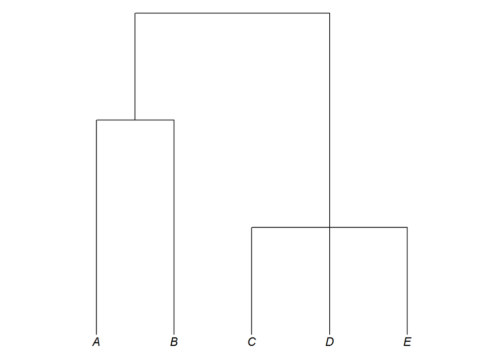

```r
plot_glotto(my_multiPhylo[[2]])
```

Before concluding this section, a final word is in order about the irrelevance of the left-to-right arrangement of trees. In a tree, there is no meaningful difference between (A,B) and (B,A): in both, A and B are sisters under a shared parent node. Similarly, these are all equivalent: (A,B,C), (A,C,B), (B,A,C), (B,C,A), (C,A,B) and (C,B,A). And likewise, these are all equivalent: (A,(B,C)), (A,(C,B)), ((B,C),A) and ((C,B),A).

# 2 Genealogically-sensitive averages and proportions

We now turn to the calculation of genealogically-sensitive proportions and averages. To begin, consider these six trees, which represent six different hypotheses about the genealogical relationships between languages `A`, `B`, `C` and `D`. Also plotted here are the languages’ dominant word orders and their numbers of consonant phonemes.

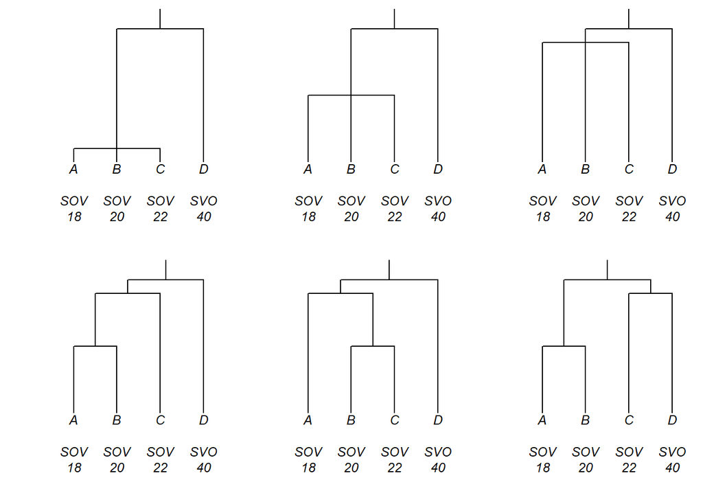

Questions that we seek to answer are: what is the proportion of this set of languages that is SOV?; and what is the average number of consonant phonemes in this set of languages? Moreover, we want the answers to be sensitive to genealogy, and we’re interested in how the answers may vary according to which of these six genealogical hypotheses is adopted.

Calculating genealogically-sensitive averages and proportions will require two key components:

1. A `phylo` or `multiPhylo` object containing one or more trees.
2. A dataframe, which (i) contains the typological data to be averaged and (ii) relates that data to the tips of the trees.

```r
multiPhylo_ABCD <-
  c(read.tree(text = "(((A:0.2,B:0.2,C:0.2):1.8,D:2):0.3);"),
    read.tree(text = "(((A:1,B:1,C:1):1,D:2):0.3);"),
    read.tree(text = "(((A:1.8,B:1.8,C:1.8):0.2,D:2):0.3);"),
    read.tree(text = "((((A:1,B:1):0.8,C:1.8):0.2,D:2):0.3);"),
    read.tree(text = "(((A:1.8,(B:1,C:1):0.8):0.2,D:2):0.3);"),
    read.tree(text = "(((A:1,B:1):1,(C:1.8,D:1.8):0.2):0.3);")
    )
```

The dataframe can be manually defined or be read from a file. Perhaps the easiest method is to read from a file that you have created and saved in “CSV” (comma separated value) format. CSV files can be created in commercial spreadsheet software like Excel, and then read by R using the `read.csv()` function like this:

```r
my_dataframe <- read.csv("my_csv_file.csv")
```

The dataframe must contain one column named `tip` (note that in R, names of columns and other objects are case sensitive) plus at least one column containing numerical data. The contents of the `tip` column must be the same as the tip labels of the tree(s) in the `phylo` or `multiPhylo` object. The contents of the numerical columns will depend on whether a proportion or an average is desired. To calculate a proportion, fill a numerical column with 1 if the language possesses the property and 0 if it does not. To calculate an average, fill a numerical column with the values of the variable for each language.

For this example, the dataframe required is defined in the code below. In addition to the `tip` column, it contains two numerical columns, `is_SOV` and `n_consonants`. As good housekeeping, we recommend using column names of the form `is_X` or `has_X` for columns that contain data for proportions, and names of the form `n_X` for columns that contain counts to be averaged.

```r
data_ABCD <- data.frame(tip = c("A", "B", "C", "D"),
                        is_SOV = c(1, 1, 1, 0),
                        n_consonants = c(18, 20, 22, 40),
                        stringsAsFactors = FALSE)
```

Genealogically-sensitive averages and proportions are obtained using the `phyloWeights` function `phylo_average()`, specifying its arguments `phy` and `data` as in the example below. Here we have assigned the output of this function to a new object `results_ABCD`. We recommend always assigning the output of `phylo_average()` to an object. We will see below how to extract from it the various parts of the results.

```r
results_ABCD <- phylo_average(phy = multiPhylo_ABCD, data = data_ABCD)
```

The function `phylo_average()` may take up to several minutes to run if the tree is large, or many trees are provided. It will return error messages if the inputs provided to it are not what is required.

The results object will contain several parts, which can be accessed using the `$` operator. In `$phy` will be the tree(s) that were supplied and in `$data` will be the dataframe that was supplied, e.g.:

```r
results_ABCD$data
```

[output not shown]

In `$ACL_averages` is a dataframe containing the genealogically-sensitive averages/proportions according to the ACL method. The dataframe has one row per tree and one column for each of the numerical columns in the `data` dataframe. Here you can see how the answer to our questions changes as the hypotheses about the tree changes.

```r
results_ABCD$ACL_averages
```

[output not shown]

In `$BM_averages` appear the genealogically-sensitive averages or proportions obtained using the BM method:

```r
results_ABCD$BM_averages
```

[output not shown]

In terms of their inner workings, both methods work by assigning weights to languages, and those weights then reflect how much each language contributes to the final result. These weights can be found in `$ACL_weights` and `$BM_weights`. You might like to compare, for each tree, the weights for languages `A`, `B`, `C`, `D` with the positions of the languages in the tree, in order to get an idea of how the weights relate to the tree shape.

```r
results_ABCD$ACL_weights
results_ABCD$BM_weights
```

[output not shown]

It is possible to save any of these dataframes to a file using the `write.csv()` function, for example:

```r
write.csv(results_ABCD$ACL_averages, file = "my_ACL_averages.csv")
```

# 3 Using and adapting trees from glottolog.com

As we have seen, using phylogenetic comparative methods, such as methods for calculating genealogically-sensitive averages, requires us to have one or more trees, expressing hypotheses about genealogical relationships among the languages. In this section we address the questions, where can linguists obtain their trees from?; and how can linguists adapt those trees to reflect their own hypotheses about language relatedness?

Our starting point is glottolog.com (Hammarström et al. 2021), a major online publication which contains many useful resources for quantitative typology. The R package `glottoTrees` (E. R. Round 2021a) has been written to help linguists make the most of these resources, including by modifying them as they desire. This section covers the glottolog data itself and the functionality of `glottoTrees`. We introduce glottolog’s genealogical data in Section @ref(glottolog-genealogical), discussing how to locate metadata about languages and families of interest, and how to view glottolog’s linguistic family trees. Since genealogically-sensitive averages and proportions require all of the languages in the study to be linked in a tree, we then discuss how glottolog’s individual trees can be combined into larger, composite trees in Section @ref(combining-trees). Since typological studies will often examine language varieties at a level of granularity that differs from glottolog’s own, in Section @ref(filter-tips) we discuss how to add and remove languages from trees. In Section @ref(add-lengths) we discuss how to add branch lengths to trees, since branch lengths are necessary for the calculation of genealogically-sensitive averages and proportions. Section @ref(exporting) discusses how to export trees for use with other software.

## 3.1 Glottolog’s genealogical data

Glottolog provides metadata about the world’s language varieties, their division into language families and the hierarchical subgrouping of languages inside those families. Naturally, there are many points of contention in linguistics about what the world’s stock of languages and dialects actually is, how it groups into families, and how the families themselves are subgrouped. Glottolog provides one set of answers, and structures them in a way which provides typologists with a basis for carrying out changes to suit their own hypotheses. In later sections we will see how this can be done. In this section we describe glottolog’s own global linguistic metadata.

At time of writing, the current version of glottolog is v4.4. The `glottoTrees` package contains a copy of the v4.4 metadata covering language names, language identification codes, family names, geographical groupings, and family trees. The original metadata files that contain this information are currently available at https://glottolog.org/meta/downloads, where a file named `tree_glottolog_newick.txt`[^2] contains glottolog’s trees, and `languages_and_dialects_geo.csv` provides geographical metadata.

Language metadata can be accessed using the `glottoTrees` function `get_glottolog_languages()`. This function returns a dataframe of close to twenty-six thousand rows. To view it in full, we suggest saving it to a CSV file and opening it in spreadsheet software such as Excel:

```r
language_metadata <- get_glottolog_languages()
write.csv(language_metadata, "language_metadata.csv")
```

Here are the first ten rows:

```r
language_metadata <- get_glottolog_languages()
head(language_metadata, n = 10)
```

[output not shown]

Listed here are glottolog’s languages, dialects, subgroups and families. These entities are identified by a name, an ISO-639-3 code if available (format: three letters) and a glottolog-specific *glottocode* (format: four letters followed by four digits[^3]). Also described is the entity’s relationship to a glottolog tree: the representation of its name in the tree (which may differ slightly from the name used elsewhere by glottolog[^4]), its position (as tip or node), and the tree’s number and name.

By default, the metadata functions in `glottoTrees`, such as `get_glottolog_languages()`, will return information about the most recent version of glottolog which the package contains. To access older versions, supply the version number via the `glottolog_version` argument:[^5]

```r
language_metadata_v4.3 <- get_glottolog_languages(glottolog_version = "4.3")
head(language_metadata_v4.3, n = 10)
```

[output not shown]

Briefer metadata about glottolog’s language families can be accessed using the `glottoTrees` function `get_glottolog_families()`. This returns a dataframe of 420 rows, so to view it in full, we also suggest saving it to a CSV file and opening it in spreadsheet software. Here are the first ten rows:

```r
family_metadata <- get_glottolog_families()
head(family_metadata, n = 10)
```

[output not shown]

Glottolog v4.4 divides the world’s languages into 420 families, including 138 isolates, and it provides a tree for each. Together, the 420 trees contain 8,209 internal nodes and 17,008 tips, many of which represent varieties that would typically be considered dialects. Geographically, glottolog assigns each language variety to one of six *macroareas*: Africa, Australia, Eurasia, Papunesia, South America or North America. The `glottoTrees` metadata includes a column `main_macroarea`. This is the one macroarea which contains more of the family’s language varieties than any other. We will see how this information can be useful in Section @ref(combining-trees).

Glottolog’s 420 family trees are stored in a `multiPhylo` object named `glottolog_trees_v4.4`. For example, here is glottolog’s representation of the Great Andamanese family, which is tree 340 within the object `glottolog_trees_v4.4`. For readability, we plot this tree horizontally:

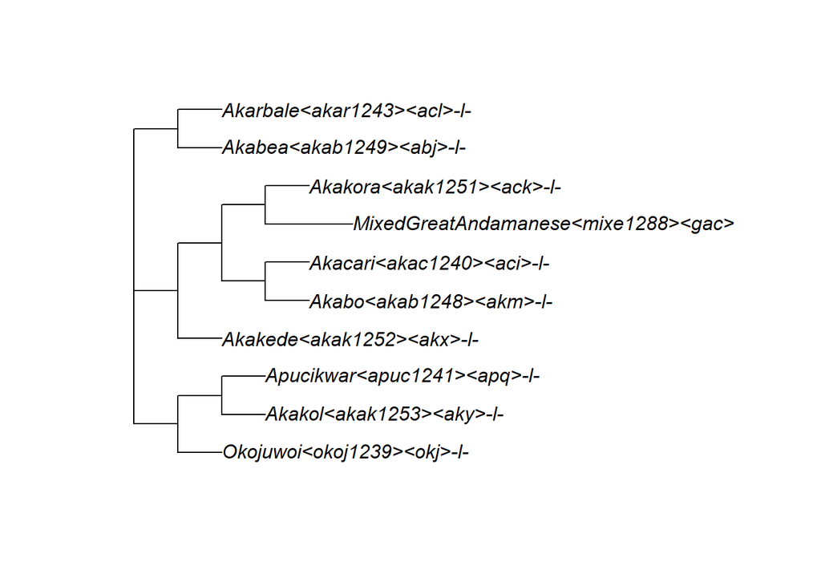

```r
tree_GA <- glottolog_trees_v4.4[[340]]
plot(tree_GA, x.lim = c(-0.3, 14))
```

Just above, we obtained the tree for Great Andamanese by referring to its tree number (340) in the `glottolog_trees_v4.4` object. The package `glottoTrees` also provides a function `get_glottolog_trees()` which enables trees to be obtained using the glottolog name for their families, for instance:

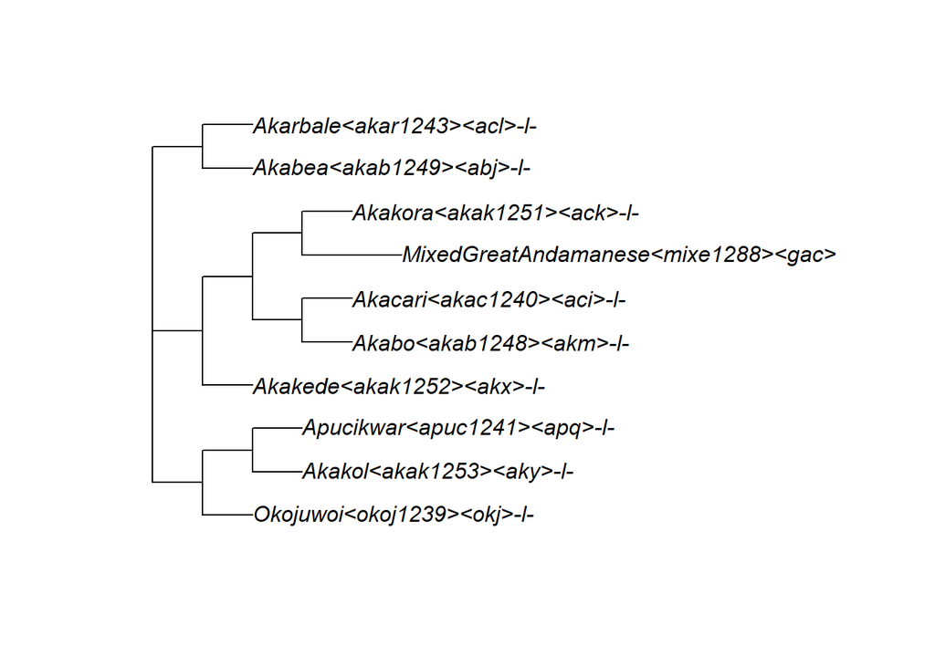

```r
tree_GA <- get_glottolog_trees("GreatAndamanese")
plot(tree_GA, x.lim = c(-0.3, 14))
```

If you know the name of one or more families and would like to now the number of their trees, use `which_tree()`:

```r
which_tree("GreatAndamanese")
```

```
## GreatAndamanese
##             340
```

```r
which_tree(c("Turkic", "Tupian", "Tuu"))
```

```
## Turkic Tupian    Tuu
##    217     32     76
```

Both `get_glottolog_trees()` and `which_tree()` allow the usage of a `glottolog_version` argument, to refer to older versions of glottolog. For instance, here are the tree numbers of the same families in version 4.1:

```r
which_tree("GreatAndamanese", glottolog_version = "4.1")
```

```
## GreatAndamanese
##               6
```

```r
which_tree(c("Turkic", "Tupian", "Tuu"), glottolog_version = "4.1")
```

```
## Turkic Tupian    Tuu
##     66    297     80
```

In glottolog’s trees, the tip labels are rather long, consisting of a name followed by a glottocode in angled brackets, an ISO code in angled brackets (if one exists) and possibly the string “-l-”. Node labels (not shown in the tree above) have the same structure. The `glottoTrees` function `abridge_labels()` will shorten labels to just the glottocode, for example:

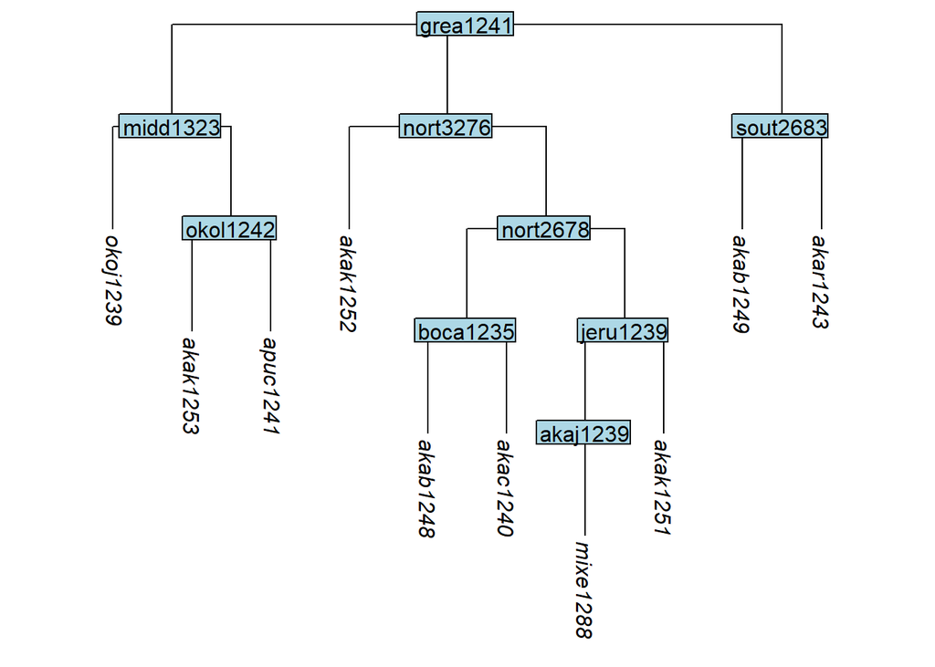

```r
tree_GA_abr <- abridge_labels(tree_GA)
plot_glotto(tree_GA_abr)
```

The function `abridge_labels()` will issue a warning if there are tip or node labels in which it is unable to identify a glottocode. We will see an example of this shortly below.

In glottolog’s trees, the branches are all of equal length. We will discuss how to assign more realistic branch lengths in Section @ref(add-lengths).

## 3.2 How to combine trees

As discussed Macklin-Cordes and Round (2021a), the comparison of languages across language families unavoidably carries a commitment to a genealogical hypothesis, even if that hypotheses is, tacitly, that all families are equally (un)related. Given that making such hypotheses is unavoidable, it will be most beneficial for progress in the field to make them explicit. To enable typologists to explore genealogical hypotheses and to make those hypotheses explicit, `glottoTrees` provides tools for combining multiple glottolog trees into one.

To begin with a small example, here we combine five glottolog families to represent the hypothesised Arnhem group in northern Australia (Green 2003). First we create a `multiPhylo` object containing the five glottolog language families (Gunwinyguan, Mangarrayi-Maran, Maningrida, and the isolates Kungarakany and Gaagudju):

```r
arnhem_family_names <-
  c("Gunwinyguan", "Mangarrayi-Maran", "Maningrida", "Kungarakany", "Gaagudju")
multiPhylo_arnhem <- get_glottolog_trees(arnhem_family_names)
```

The `glottoTrees` function `assemble_rake()` enables the trees in a `multiPhylo` object to be assembled into a single tree with a rake structure at its root. Here we apply `assemble_rake()` to our `multiPhylo` object and assign the resulting, single tree to the object `tree_arnhem`.

```r
tree_arnhem <- assemble_rake(multiPhylo_arnhem)
```

For plotting, it will be convenient to shorten the labels in the tree to just the glottocodes, using `abridge_labels()`. However, the root node in our newly created tree `tree_arnhem` has no label. Accordingly, the function `abridge_labels()` will issue a warning, that it encountered one node without a glottocode. This is not an error message, and `abridge_labels()` still shortens all labels to glottocodes where it can; it is just flagging the fact that it was not able to do so in all cases.

```r
tree_arnhem_abr <- abridge_labels(tree_arnhem)
```

```
## Warning in abridge_labels(tree_arnhem): Labels without glottocodes were detected and left
## unchanged for: 0 tip(s); 1 node(s):
```

Plotting the resulting tree enables us to inspect our newly created Arnhem tree. Note how all five families are joined to the root in a rake-like structure, without any additional subgrouping.

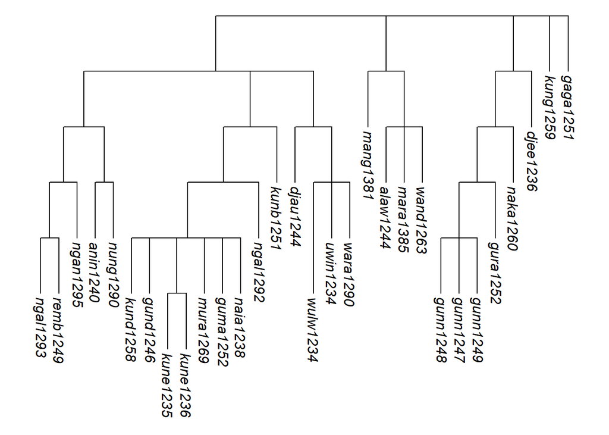

```r
plot_glotto(tree_arnhem_abr, nodelabels = FALSE)
```

It is possible to give a combined tree more structure, by using `assemble_rake()` iteratively. For instance, suppose we wished to hypothesise that Gunwinyguan, Mangarrayi-Maran and Maningrida form their own subgroup. First, we create a `multiPhylo` object containing those three trees, and combine it into a single rake tree, which we call `tree_A`:

```r
multiPhylo_A <- get_glottolog_trees(c("Gunwinyguan", "Mangarrayi-Maran", "Maningrida"))
tree_A <- assemble_rake(multiPhylo_A)
```

Then we create the final tree by combining `tree_A` with the two isolate family trees:

```r
multiPhylo_arnhem2 <- c(tree_A, get_glottolog_trees(c("Kungarakany", "Gaagudju")))
tree_arnhem2 <- assemble_rake(multiPhylo_arnhem2)
tree_arnhem2_abr <- abridge_labels(tree_arnhem2)
```

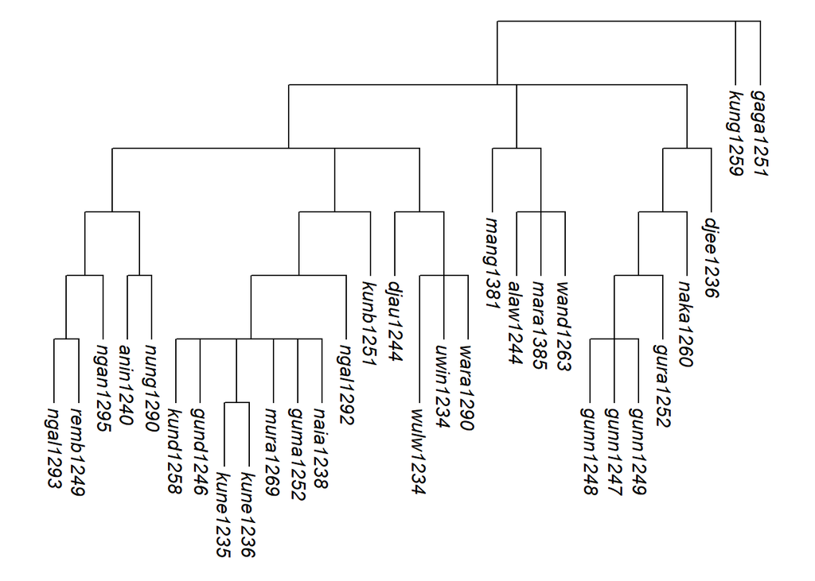

```r
plot_glotto(tree_arnhem2_abr, nodelabels = FALSE)
```

Typological studies often examine languages from very many families. To group all 420 families into a single ‘supertree’, `glottoTrees` provides the function `assemble_supertree()`. By default, the function returns a supertree that divides first into glottolog’s six macroareas, with an internal node for each, and directly below these macroarea nodes appear all of the glottolog families, grouped by their `main_macroarea` mentioned in Section @ref(glottolog-genealogical) above. This tree is enormous, so we do not plot it here. It is obtained like this:

```r
my_supertree <- assemble_supertree()
```

The highest-level, macroarea groupings can also be controlled through the function’s argument `macro_groups`. For instance, to group all of the world’s families directly into a 420-pronged rake structure, set `macro_groups = NULL`:

```r
my_supertree <- assemble_supertree(macro_groups = NULL)
```

It is also possible to group macroareas together, for example, to combine North and South America into a single group. Grouping of macroareas is achieved by setting the `macro_groups` argument to a *list* whose items are the desired groups of macroareas. Each group will then appear as one of the highest-level nodes of the tree, and all of its families below it. For instance, to keep all of glottolog’s macroareas separate, but to combine North and South America into a single group, the following code would be used. First we define a list, which we’ve called `my_list`, within which any groupings containing more than one macroarea are represented as a vector, using the `c()` function:

```r
my_list <- list("Africa", "Australia", "Eurasia", "Papunesia",
                c("South America", "North America"))
```

We then use that list as the `macro_groups` argument of `assemble_supertree()`:

```r
my_supertree <- assemble_supertree(macro_groups = my_list)
```

Taking a second example, to create a supertree containing only the families whose `main_macroarea` is either Africa or Eurasia, and to place Africa and Eurasia under separate, highest-level nodes, we would use:

```r
my_list <- list("Africa", "Eurasia")
my_supertree <- assemble_supertree(macro_groups = my_list)
```

## 3.3 How to modify trees

There are several reasons why typologists may wish to use a tree that departs from the glottolog trees. Most commonly, a typological study will cover a set of languages that differs from the set of tips in any single glottolog tree, either through the exclusion of some of the lects that glottolog represents as tips or through the distinction of additional lects. A third case that can arise is when glottolog places one or more dialects at the tree’s tips and more a general, language node above them. The typologist may have data that applies to the language (an internal node) rather than the dialects (the tips), yet the calculation of genealogically-sensitive averages and proportions requires one’s typological variables to be related to the tips of trees, not to internal nodes. In these cases and many others, the typologist may wish to alter the glottolog tree to suit the purposes of the research. The `glottoTrees` package supplies a set of functions to aid in performing each of these tree manipulations. In this section we introduce them and illustrate their use.

In the following examples, we will make use glottolog’s representation of the Great Andamanese family, whose labels we shorten to just the glottocodes using `abridge_labels()`:

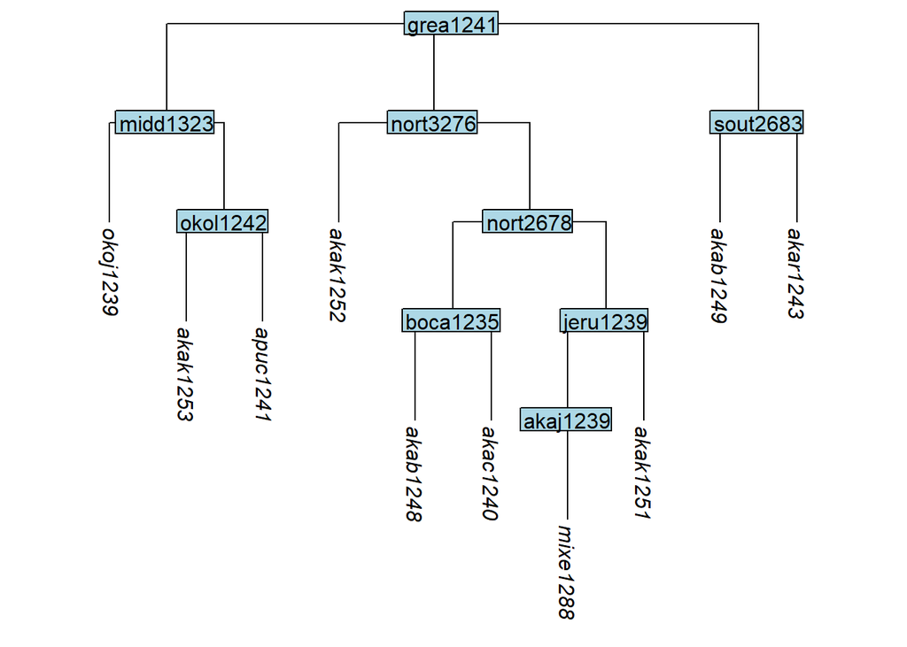

```r
tree_GA <- get_glottolog_trees("GreatAndamanese")
tree_GA_abr <- abridge_labels(tree_GA)
plot_glotto(tree_GA_abr)
```

### 3.3.1 How to remove tips

Firstly, we illustrate the removal of tips from a tree. There are two functions in `glottoTrees` for doing this. The function `remove_tip()` works by specifying which tips are to be removed, while the function `keep_tip()` works by specifying which tips are to be retained. First we will remove three of the original ten tips in the Great Andamanese tree. We do this by setting the `label` argument of `remove_tip()` to a vector containing the labels of the tips to be removed. Within the vector, the labels can appear in any order.

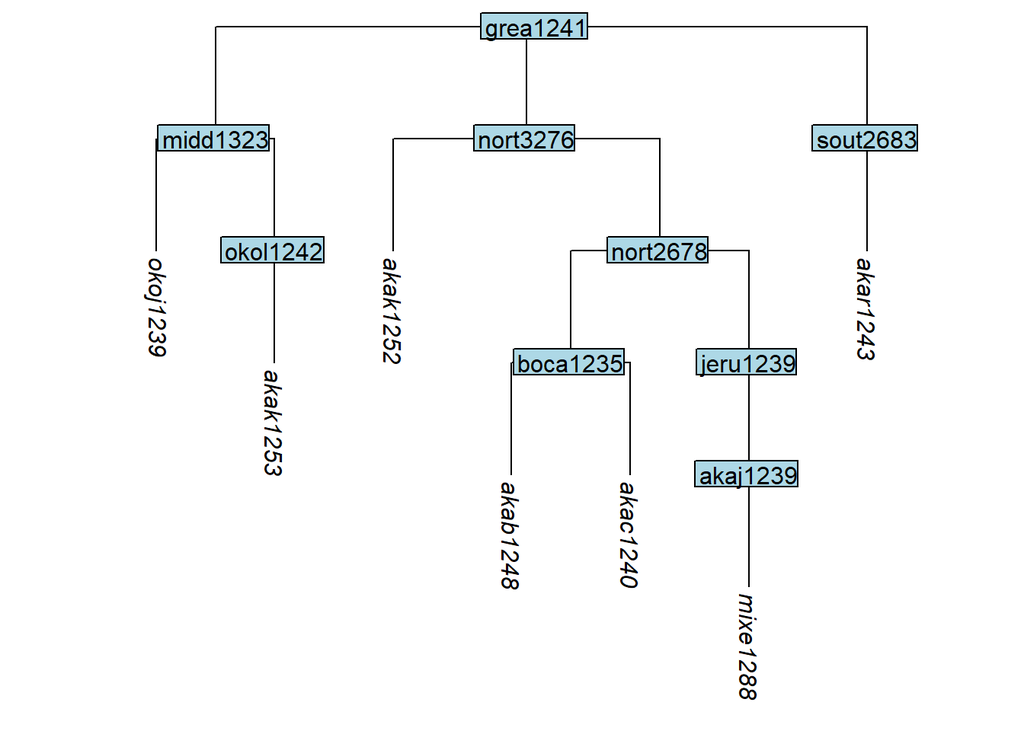

```r
tree_GAa <- remove_tip(tree_GA_abr, label = c("akab1249", "akak1251", "apuc1241"))
plot_glotto(tree_GAa)
```

In this next example, we remove the tips `akab1249` and `akar1243`. These tips are the only tips that sit below the internal node `sout2683`. This is significant, because it triggers a convention in tree manipulation, that if all tips below a node are removed, then the node is removed also. We see that here:

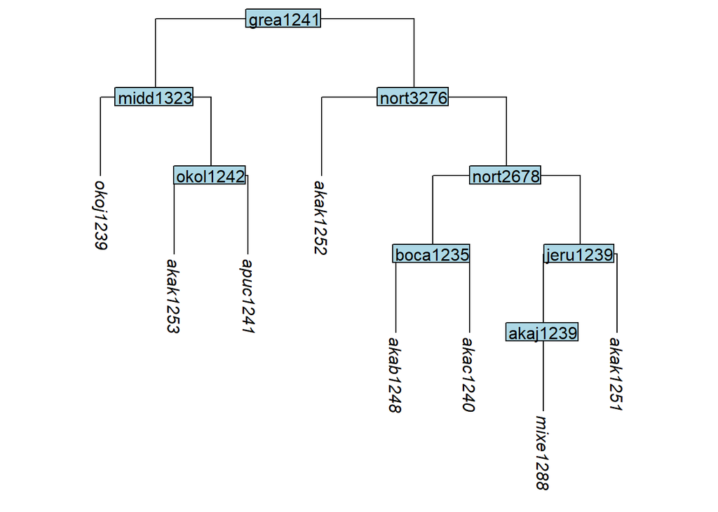

```r
tree_GAb <- remove_tip(tree_GA_abr, label = c("akab1249", "akar1243"))
plot_glotto(tree_GAb)
```

We now illustrate the usage of the `glottoTrees` function `keep_tip()`. Here we use it to retain six of the original ten tips in the Great Andamanese. We do this by setting the `label` argument to a vector containing the labels of the six desired tips.

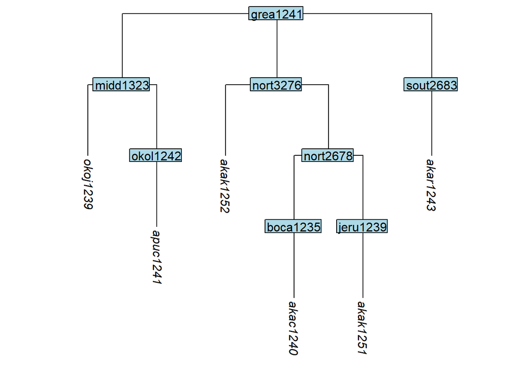

```r
tree_GAc <- keep_tip(tree_GA_abr, label = c("akar1243", "akak1251", "akac1240",
                                            "akak1252", "apuc1241", "okoj1239"))
plot_glotto(tree_GAc)
```

As before, if our use of `keep_tip()` results in a node having all of the tips below it removed, then the node will also be removed automatically. This is illustrated here, where the node `boca1235` is removed automatically because neither of the tips below it are kept:

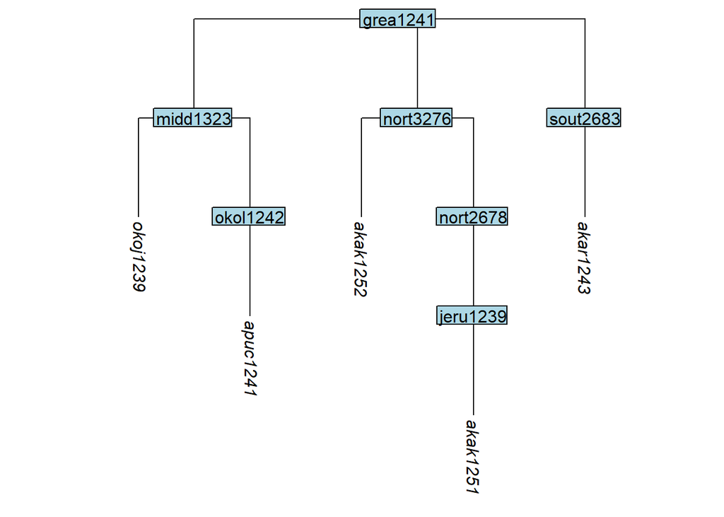

```r
tree_GAd <- keep_tip(tree_GA_abr, label = c("akar1243", "akak1251", "akak1252",
                                            "apuc1241", "okoj1239"))
plot_glotto(tree_GAd)
```

### 3.3.2 How to remove tips and convert nodes to tips

As mentioned earlier, many of the tips in glottolog’s trees correspond to dialects, with languages represented as nodes above the dialectal tips. One usage case we foresee is that a typologist will wish to study a set of language varieties, some of which correspond to glottolog’s tips and some of which correspond to nodes. The `glottoTrees` function `keep_as_tips()` takes an argument `label` which can contain both tip labels and node labels. Any tips will be kept, and any nodes will be converted into tips, with all of the structure below them being removed. Be mindful when using `keep_as_tips()` that it is not possible to both convert a node into a tip and also retain the structure below it, such as tips that it dominates. Here we keep the same tips as in the tree above, while also converting the node `boca1235` into a tip:[^6]

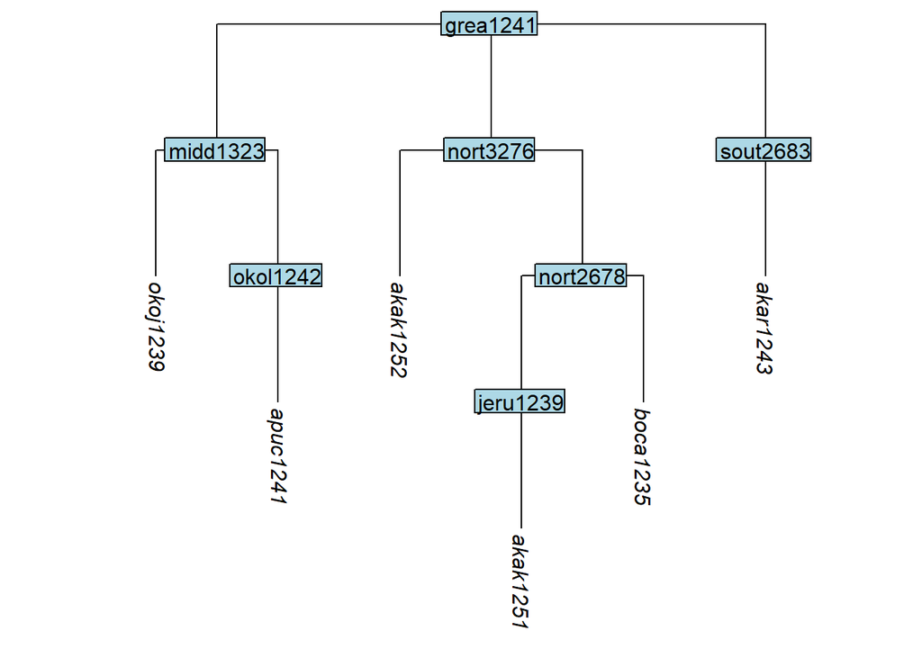

```r
tree_GAe <- keep_as_tip(tree_GA_abr, label = c("akar1243", "akak1251", "akak1252",
                                               "apuc1241", "okoj1239", "boca1235"))
plot_glotto(tree_GAe)
```

One workflow that we envision for `keep_as_tip()` is that the typologist has prepared a CSV file, one of whose columns is named `tip` and contains the glottocodes of all the language varieties in the study. This CSV file can be loaded in R and assigned to a dataframe, and then its `tip` column can be passed to `keep_as_tip()` as the value of the `labels` argument, like this:

```r
my_dataframe <- read.csv("my_data_file.csv", stringsAsFactors = FALSE)
my_new_tree <- keep_as_tip(my_old_tree, label = my_dataframe$tip)
```

To just convert one or more nodes into tips, use `convert_to_tip()`, as we do here to convert the nodes `okol1242` and `sout2683` to tips:

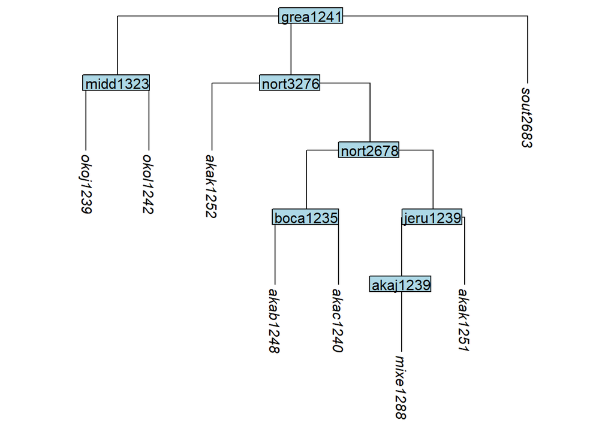

```r
tree_GAf <- convert_to_tip(tree_GA_abr, label = c("okol1242", "sout2683"))
plot_glotto(tree_GAf)
```

### 3.3.3 How to remove internal nodes

Sometimes, the removal of tips will cause one or more of the remaining tips to sit below a node which dominates only it. This reflects that fact that `remove_tip()`, `keep_tip()` and `keep_as_tip()` all preserve the original *depth* of any tips that remain in the tree (you may like to confirm this by reviewing the plots above). Depending on the researcher’s needs, this outcome may or may not be desirable. If it is undesirable, then non-branching, internal nodes can be removed using the `glottoTrees` function `collapse_node()`. For instance, here we remove two of the non-branching nodes from the tree `tree_GAc` above, by naming them in the `label` argument of `collapse_node()`. In the resulting tree, these nodes have been removed, thus reducing the depth of the tips below them:

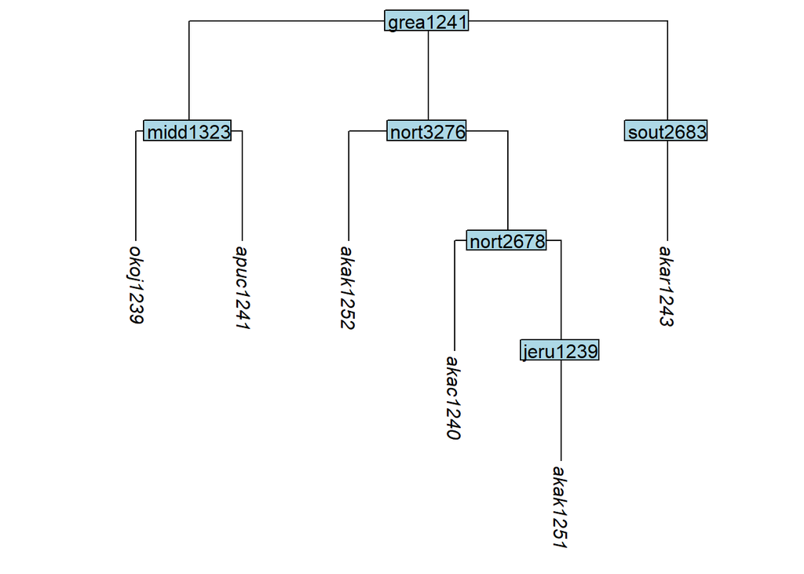

```r
tree_GAg <- collapse_node(tree_GAc, label = c("boca1235", "okol1242"))
plot_glotto(tree_GAg)
```

When deciding whether to collapse nodes, in can be handy to know which nodes in a tree that have only one child below them. The function `nonbranching_nodes()` will return a vector of all such nodes, for example:

```r
nonbranching_nodes(tree_GAc)
```

```
## [1] "okol1242" "boca1235" "jeru1239" "sout2683"
```

```r
nonbranching_nodes(tree_GAg)
```

```
## [1] "jeru1239" "sout2683"
```

The function `collapse_node()` can also be used to alter a subgrouping hypothesis, and specifically, to remove a layer of subgrouping, converting a nested structure ((A,B),C) into a flat structure (A,B,C). For instance, here we remove the `okol1242` node of the original glottolog Great Andamanese tree, converting its two daughter languages into sisters of `okoj1239`:

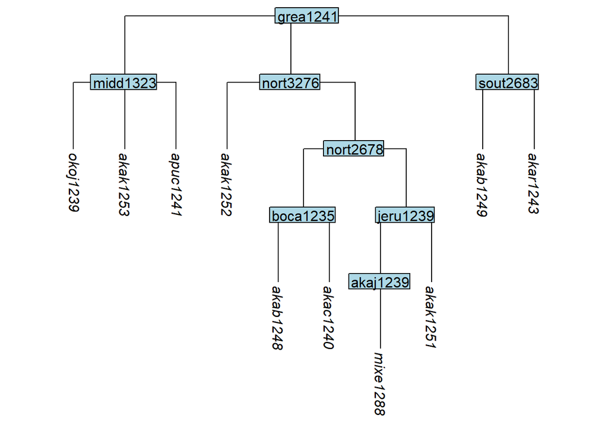

```r
tree_GAh <- collapse_node(tree_GA_abr, label= "okol1242")
plot_glotto(tree_GAh)
```

### 3.3.4 How to add tips

The function `add_tip()` allows tips to be added to a tree. The `label` argument specifies the name of the new tip, while `parent_label` specifies the label of the node below which the new tip should appear. Here we add a tip `xxxx1234` below the node `sout2683`:

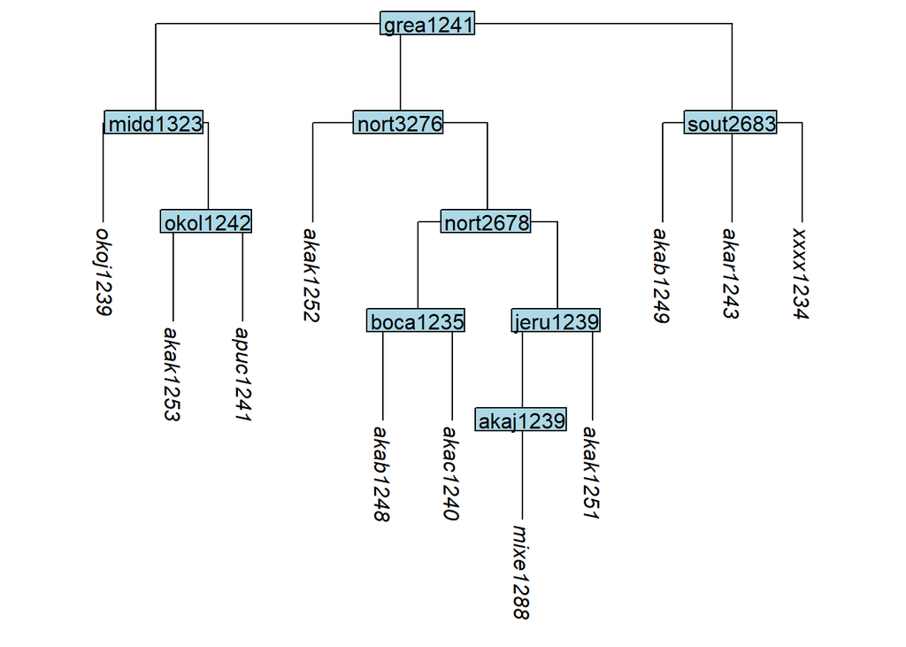

```r
tree_GAi <- add_tip(tree_GA_abr, label = "xxxx1234", parent_label = "sout2683")
plot_glotto(tree_GAi)
```

### 3.3.5 How to clone tips

Next we illustrate the cloning of tips. Cloning tips may be useful when glottolog provides only one glottocode, and thus only one tree tip, corresponding to multiple lects in the typologist’s study. To clone a tip, use the function `clone_tip()` and in the `label` argument, provide a vector of the tips to be cloned. Here we clone tips `akar1243` and `akak1252`:

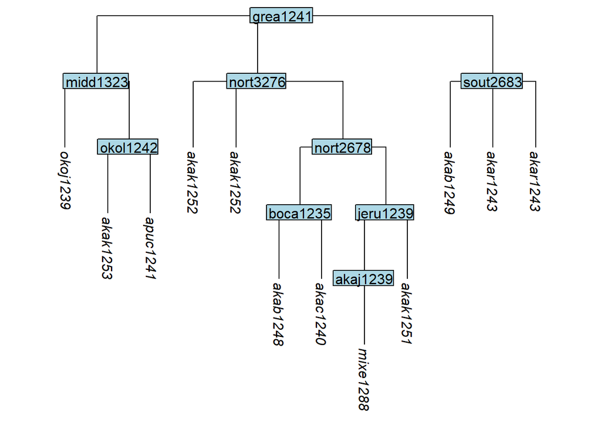

```r
tree_GAj <- clone_tip(tree_GA_abr, label = c("akar1243", "akak1252"))
plot_glotto(tree_GAj)
```

By default, clones are added to the tree as sisters directly beneath the parent node of the original tip. An alternative is to create a new subgroup for each set of sister clones, using the `subgroup` argument and setting it to `subgroup = TRUE`. Each newly created subgroup node is given a label that matches the cloned tips it dominates:

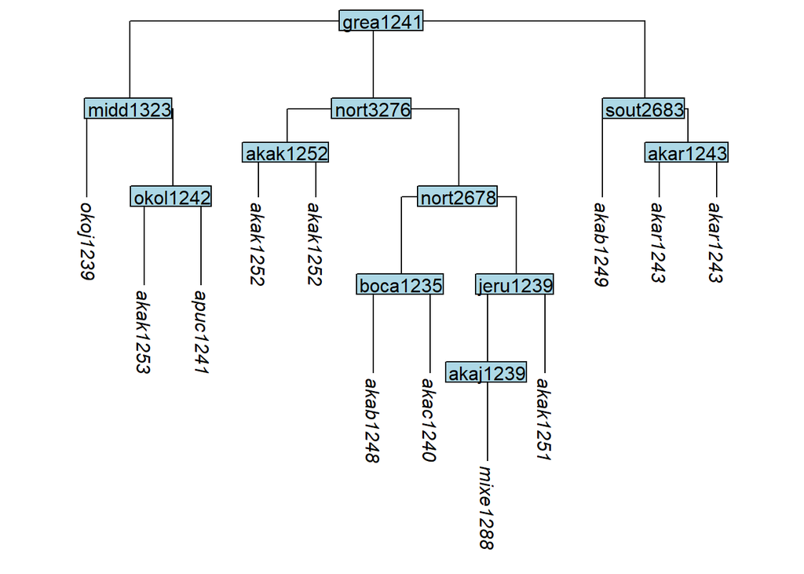

```r
tree_GAk <- clone_tip(tree_GA_abr, label = c("akar1243", "akak1252"), subgroup = TRUE)
plot_glotto(tree_GAk)
```

It is also possible to make more than one clone using the `n` argument. Here we create three new clones of `akab1248` and place them in a subgroup:

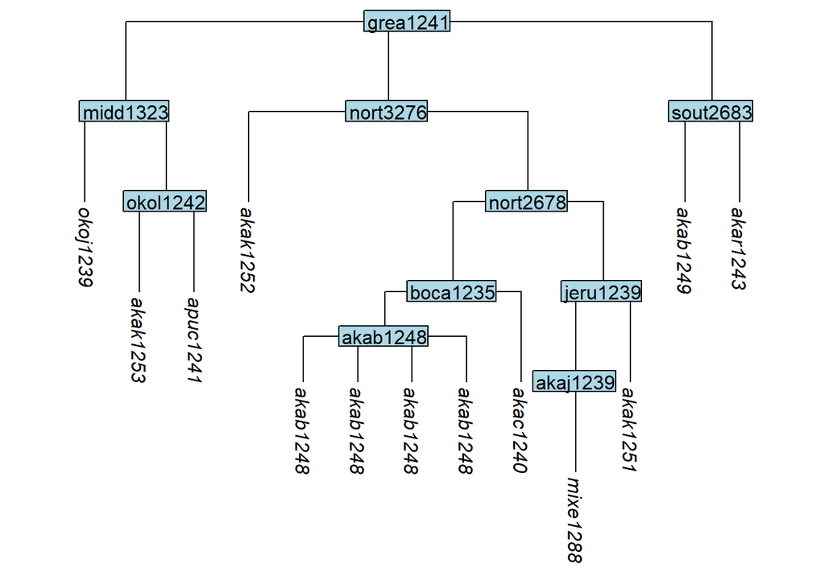

```r
tree_GAl <- clone_tip(tree_GA_abr, label = "akab1248", n = 3, subgroup = TRUE)
plot_glotto(tree_GAl)
```

One of the consequences of cloning tips is that the in the resulting tree, not all tips will have distinct names. The function `apply_duplicate_suffixes()` will add a suffix to any tips with duplicate labels, to make them unique.[^7] The suffix will consist of a hyphen followed by a number. Here we add suffixes to the tree `tree_GAj`:

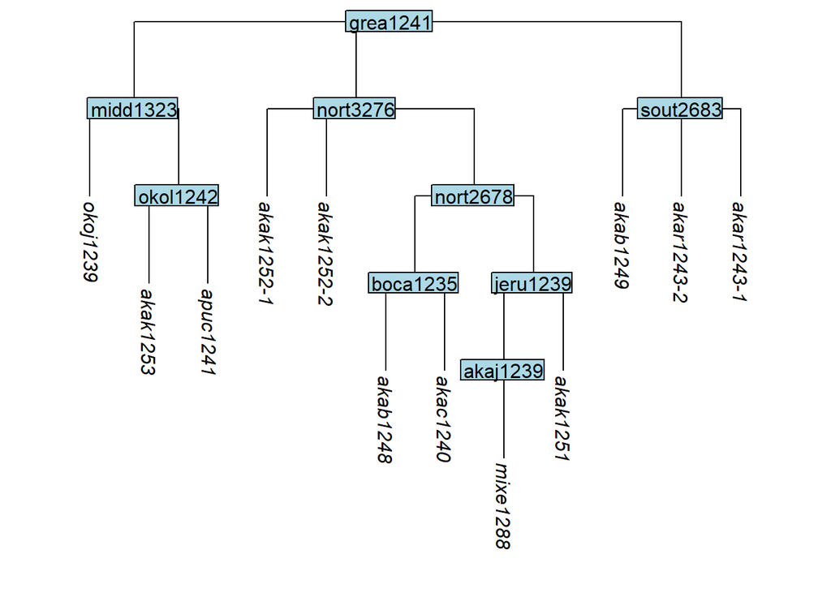

```r
tree_GAm <- apply_duplicate_suffixes(tree_GAj)
plot_glotto(tree_GAm)
```

### 3.3.6 How to move a tip

Using the function `move_tip()`, a tip can be moved to a new position, beneath a new parent node (one of the nodes already in the tree) which is specified with the `parent_label` argument:

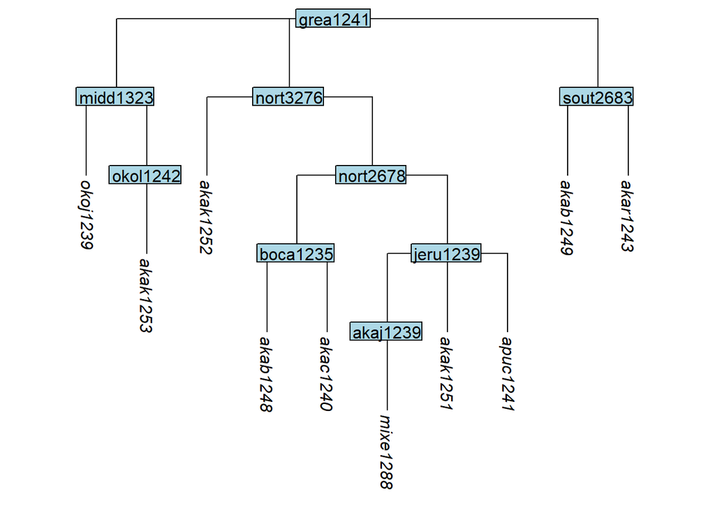

```r
tree_GAn <- move_tip(tree_GA_abr, label = "apuc1241", parent_label = "jeru1239")
plot_glotto(tree_GAn)
```

### 3.3.7 How to move a node and its descendants

In a similar fashion, the function `move_node()` is used to move an internal node, along with all of the structure below it, to a position beneath a new parent node:

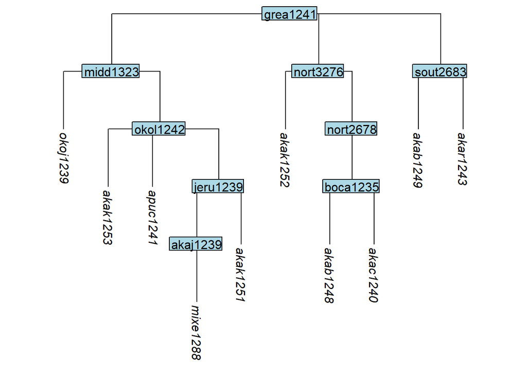

```r
tree_GAo <- move_node(tree_GA_abr, label = "jeru1239", parent_label = "okol1242")
plot_glotto(tree_GAo)
```

### 3.3.8 Summary: a general-purpose toolkit for curating trees’ topology

The functions `remove_tip()`, `keep_tip()`, `keep_as_tip()`, `convert_to_tip()`, `collapse_node()`, `add_tip()`, `clone_tip()`, `move_tip()` and `move_node()` provide a general-purpose toolkit for modifying a single glottolog tree, or a combined tree, or supertree, to make its set of tips, and the subgrouping of those tips, conform to the set of lects that a typologist is analysing in a typological study.